# Week 04 - Social network analysis

- Show All Code
- Hide All Code

Theoretical Insights and it’s Measurements

```r
library(needs)
needs(igraph,
      igraphdata,
      netseg)
data("UKfaculty")
```

Welcome to this session of the seminar **CSS**!

# Relational Sociology and the concept of embeddedness

Different theories on roles and conflicts between roles draw on this idea, that society exists were different individuals interact with each other. Economic, social, and political actions are embedded in social networks and relationships. This means that individuals and organizations are not isolated actors, but are instead part of a larger web of social connections that shape their behavior and decision-making.

## Social capital

*Social Capital* as a concept goes back to the work of Pierre Bourdieu (1986). Its is not such a crisply defined term as it may seem. But basically, the concept boils down to the access to resources through the social network. In the most simple terms we could operationalize this as the resources possessed by the (direct) social ties of ego. We can roughly differentiate two dimensions along which major definitions of social capital can be categorized: **resources** vs. **structure**, and a focus on the individual capital vs group capital. (Lin 2001) provides a good overview of the general concept.

The structural based approach mainly dates back to (Coleman 1958) who proposed that the social capital should be operationalized as the cohesion of a network or a subgroup. He claimed that cohesion produces trust, predictability and enables cooperation. This draws on Rational Choice Theory and proposes stable, cohesive groups with visibility of each others behavior as a prevention of defection. See network cohesion measures for descriptives.

While addressing a similar problem as Coleman, Robert Putnam (Putnam 2001) claims that groups (and indirectly the individuals in them) need civic engagement. As such, this approach focuses less on the structural properties of the network and more on what people do/ bring into the network. Hence the label “resource-based approach”. A simple way to do this is to calculate average levels of, e.g., voter turnout or participation in civic organizations per group or sub-group.

The structural approach on the individual level relates mainly to the works of Mark Granovetter (1973) and Ronald Burt (1995). Granovetter’s work on the strength of weak ties and Burt’s work on structural holes are two of the most influential theories in social network analysis. Granovetter’s theory suggests that weak ties (acquaintances) can be more valuable than strong ties (close friends) in terms of information flow and access to new opportunities. Burt’s theory emphasizes the importance of being a broker or connector between different groups in a network, which can lead to greater access to resources and information.

# Tie formation and social capital

## Reciprocity

Measures of reciprocity are based on the **dyad census**: Any pair of vertices in a network is called a dyad. There are three possible states of dyads (in a directed network): null dyads (no edge), b) asymmetric dyads (one directed edge) and c) mutual dyads (two directed edges).

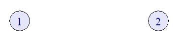

Null dyad

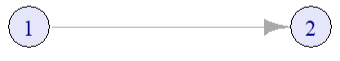

Assymetrical dyad

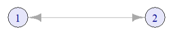

Mutual dyad

Figure 1

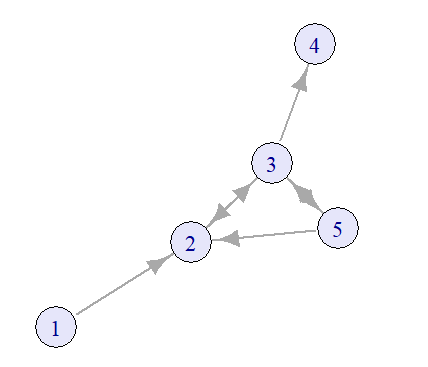

Example dyads

| null | asymmetric | mutual |
| --- | --- | --- |
| 5 | 3 | 2 |

```r
null <- graph_from_literal(1, 2)
as <- graph_from_literal(1-+2)
mutual <- graph_from_literal(1-+2, 2-+1)

g <- graph_from_literal(1-+2, 2-+3, 2+-3, 5-+2, 3--+5, 5-+3, 3-+4)

layout_line <- cbind(1:2, rep(1, 2))

plot(null,
     vertex.color = "lavender",
     vertex.size = 30,
     layout = layout_line)

plot(as,
     vertex.color = "lavender",
     vertex.size = 30,
     layout = layout_line)

plot(mutual,
     vertex.color = "lavender",
     vertex.size = 30,
     layout = layout_line)

# Plotte das Netzwerk mit Lavender vertices
plot(g,
     vertex.color = "lavender",
     vertex.size = 30,
     edge.width = 2,
     arrow.size = 0.1,
     layout = layout_with_fr)
```

### Dyad census in a graph

```r
dyad_census(g)

UKfaculty <- upgrade_graph(UKfaculty)
UKfaculty <- simplify(UKfaculty)

dyad_census(UKfaculty)
```

The **level of reciprocity** shows whether a network mainly consists of mutual or asymetrical edges and can be calculated in R using either ‘default’-mode (number of reciprocated edges divided by the total number of edges) or ‘ratio’-mode (number of mutual dyads divided by the number of asymmetric dyads).

```r
reciprocity(UKfaculty, mode="default")

reciprocity(UKfaculty, mode="ratio")
```

Describing the relationships of nodes draws back on mathematical relations. The following table summarizes the most important relations:

| Property | Definition |
| --- | --- |
| Reflexive | ∀ a ∈ A: (a, a) ∈ R |
| Symmetric | ∀ a, b ∈ A: (a, b) ∈ R ⇒ (b, a) ∈ R |
| Transitive | ∀ a, b, c ∈ A: (a, b) ∈ R ∧ (b, c) ∈ R ⇒ (a, c) ∈ R |
| Asymmetric | ∀ a, b ∈ A: (a, b) ∈ R ⇒ (b, a) ∉ R |
| Antisymmetric | ∀ a, b ∈ A: (a, b) ∈ R ∧ (b, a) ∈ R ⇒ a = b |
| Irreflexive | ∀ a ∈ A: (a, a) ∉ R |
| Complete | ∀ a, b ∈ A: (a, b) ∈ R ∨ (b, a) ∈ R |

## Transitivity

Any set of 3 vertices in a network is called a **triad**. In directed networks, 16 different triads exist (Davis and Leinhardt 1967).

```r
# Define all 16 triad types using adjacency matrices
triad_matrices <- list(
  matrix(c(0,0,0, 0,0,0, 0,0,0), nrow=3, byrow=TRUE), # 003
  matrix(c(0,1,0, 0,0,0, 0,0,0), nrow=3, byrow=TRUE), # 012
  matrix(c(0,1,0, 1,0,0, 0,0,0), nrow=3, byrow=TRUE), # 102
  matrix(c(0,1,1, 0,0,0, 0,0,0), nrow=3, byrow=TRUE), # 021D
  matrix(c(0,0,0, 1,0,0, 1,0,0), nrow=3, byrow=TRUE), # 021U
  matrix(c(0,1,0, 0,0,1, 0,0,0), nrow=3, byrow=TRUE), # 021C
  matrix(c(0,1,0, 1,0,0, 1,0,0), nrow=3, byrow=TRUE), # 111D
  matrix(c(0,1,0, 1,0,1, 0,0,0), nrow=3, byrow=TRUE), # 111U
  matrix(c(0,1,1, 0,0,0, 0,1,0), nrow=3, byrow=TRUE), # 030T
  matrix(c(0,1,0, 0,0,1, 1,0,0), nrow=3, byrow=TRUE), # 030C
  matrix(c(0,1,1, 1,0,0, 1,0,0), nrow=3, byrow=TRUE), # 201
  matrix(c(0,1,1, 0,0,1, 0,1,0), nrow=3, byrow=TRUE), # 120D
  matrix(c(0,0,0, 1,0,1, 1,1,0), nrow=3, byrow=TRUE), # 120U
  matrix(c(0,1,1, 0,0,1, 1,0,0), nrow=3, byrow=TRUE), # 120C
  matrix(c(0,0,1, 1,0,1, 1,1,0), nrow=3, byrow=TRUE), # 210
  matrix(c(0,1,1, 1,0,1, 1,1,0), nrow=3, byrow=TRUE) # 300 (mutual all)
)

triad_names <- c("003", "012", "102", "021D", "021U", "021C", "111D", "111U", "030T", "030C",
                 "201", "120D", "120U", "120C", "210", "300")

# Plot each triad
par(mfrow = c(4, 4), mar = c(1, 1, 2, 1))  # 4x4 grid layout

for (i in 1:16) {
  adj <- triad_matrices[[i]]
  g <- graph_from_adjacency_matrix(adj, mode = "directed")
  plot(
    g,
    main = triad_names[i],
    vertex.color = "lavender",
    vertex.size = 30,
    vertex.label = NA,
    vertex.label.cex = 0,
    edge.arrow.size = 0.3,
    layout = layout_in_circle
  )
}
```

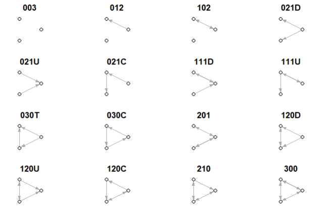

Different tryads

- Triads 201 are called **intransitive**
- Triads 300 are called **transitive**
- Triads 003 and 012 are called **vacuously transitive**

The codes like `102`, `021C`, `120U` may feel cryptic at first, but they follow a logical pattern:

- **First digit**: Number of **mutual (reciprocal)** dyads (e.g., A ↔︎ B)
- **Second digit**: Number of **asymmetric (one-way)** dyads (e.g., A → B)
- **Third digit**: Number of **null dyads** (no tie between the pair)

**Example: ‘102’**

| Digit | Meaning |
| --- | --- |
| `1` | 1 mutual (reciprocal) relationship (e.g., A ↔︎ B) |
| `0` | 0 one-way relationships |
| `2` | 2 node pairs have no relationship |

**Add-On lettering:**

For more complex cases, a letter is added to describe the triad’s shape or direction:

[output not shown]

We can compute the triad census of a network using

```r
triad_census(UKfaculty)
# nice layout
tbl <- data.frame(t(triad_census(UKfaculty)))
colnames(tbl) <- c("003", "012", "102", "021D", "021U", "021C", "111D", "111U", "030T", "030C", "201", "120D", "120U", "120C", "210", "300")
tbl
```

In undirected networks only 4 distinct triads exist.

```r
# Define the 4 undirected triad types
undirected_triad_matrices <- list(
  matrix(c(0,0,0, 0,0,0, 0,0,0), nrow=3, byrow=TRUE),  # 0 edges: Empty (Type: 003)
  matrix(c(0,1,0, 1,0,0, 0,0,0), nrow=3, byrow=TRUE),  # 1 edge: One dyad (Type: 102)
  matrix(c(0,1,1, 1,0,0, 1,0,0), nrow=3, byrow=TRUE), # 2 edges: Open triad (Type: 201)
  matrix(c(0,1,1, 1,0,1, 1,1,0), nrow=3, byrow=TRUE)  # 3 edges: Complete triad (Type: 300)
)

undirected_triad_names <- c("003", "102", "201", "300")

# Plot each undirected triad
par(mfrow = c(2, 2), mar = c(1, 1, 2, 1))  # 2x2 grid layout

for (i in 1:4) {
  adj <- undirected_triad_matrices[[i]]
  graph <- graph_from_adjacency_matrix(adj, mode = "undirected")
  plot(
    graph,
    main = undirected_triad_names[i],
    vertex.color = "lavender",
    vertex.label = NA,
    vertex.size = 30,
    vertex.label.cex = 0,
    layout = layout_in_circle
    )
}
```

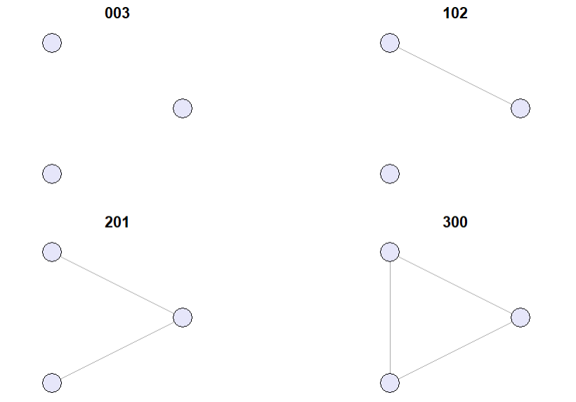

Triads in undirected networks

## Triadic closure and the transitivity tendency

**Triadic closure** is a concept in social network theory that was first introduced by Georg Simmel. It describes the tendency of two nodes $A$ and $B$ to become connected if they share a common neighbor $C$. It can be used to understand and *predict* the formation of social ties in network (of course, there are many other factors influencing tie formation).

### Clustering coefficient

A **clustering** coefficient is a measure of the degree to which vertices in a graph tend to cluster together. Evidence suggests that in most social networks, groups tend to create highly clustered subgroups.

**Global clustering coefficient** or transitivity:

In an undirected graph a connected triple is a path of length 2 (i.e. triad 201). A triangle is a cycle of exactly three nodes (i.e. triad 300). The global clustering coefficient is then defined as

$$G_g = \frac{(\text{number of triangles} \times 3)}{(\text{number of connected triples})}$$

- $C_g = 0$: no clustering
- $C_g = 1$: all triples are triangles (i.e. all connected triples are triangles)

```r
transitivity(UKfaculty, type = "global")
```

## Cognitive balance theory

It involves triads of entities typically represented as a Person $P$, another Person $O$, and and Object $X$.

If $P$ likes $X$ but dislikes $O$, and then learns that $O$ likes $X$, then $P$ will feel uncomfortable and will try to restore balance by either changing their attitude towards $O$ or $X$.

Cognitive balance is achieved, when there are three positive links or two negatives with one positive.

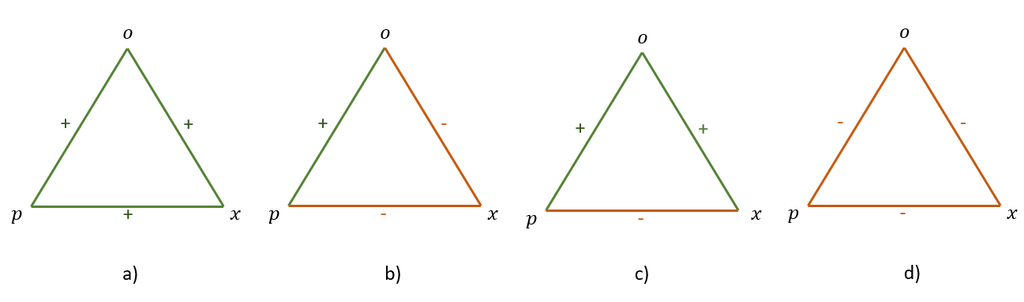

### (Strong) balance in networks

A signed graph is a graph where each edge has a sign (positive or negative). The sign of an edge can represent the nature of the relationship between two nodes. For example, in social networks, a positive edge might represent friendship, while a negative edge might represent enmity or dislike.

Cartwright and Harari(1956) extended Heider’s theory into graph theory, modeling people as nodes and their sentiments as signed edges (+ for friendship, − for hostility). They viewed triads as 3-cycles in a signed graph.

A fully signed graph is balanced, if every triad in it is balanced.

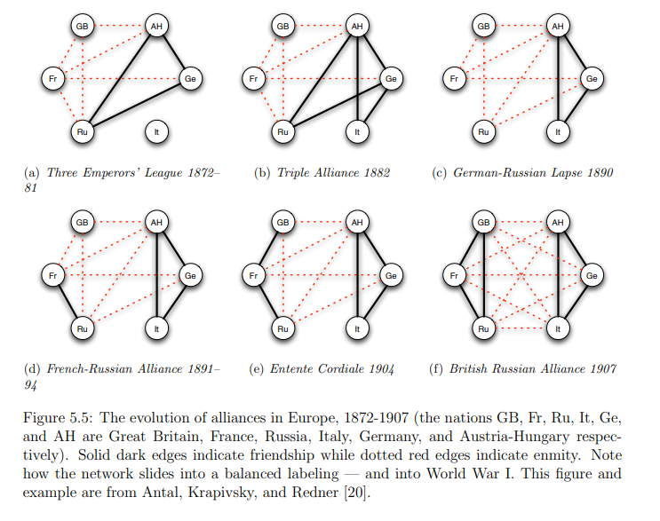

Easley and Kleinberg (2010), page 127

### Weak balance in networks

Additional assumption: A triad with three negative edges is also considered balanced (Davis 1967).

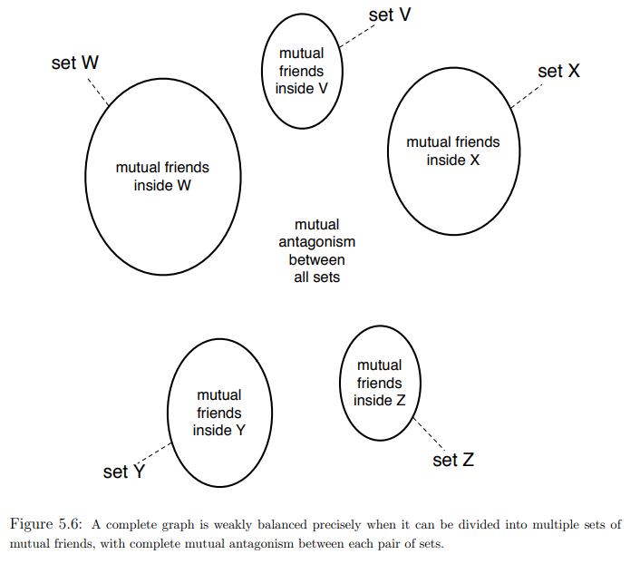

Easley and Kleinberg (2010), page 129

# Network segregation and homophily

**Segregation**: network level property-Segregation refers to the extent to which actors and social groups are separated from another. Segregation exists if the share of ties between groups is much less pronounced than the share of in-group ties, or if the groups are fully separated from each other.

[figure not shown]

Segregation in the Schelling model (preference = 55%)

Figure 2

The literature does not agree regarding the exact terminology of homophily and segregation. To some authors, **homophily** refers to both the macro-phenomenon (lack of intergroup relationships) and the micro-mechanism (similarity preferences). To others, **homophily** refers to the macro-phenomenon and **homophilic** or **homophilious selection** refer to the micro-mechanism.

I concur with other researchers on the terminology of **homophily (preferences)** for the mechanism and **segregation** for the macro-pattern.

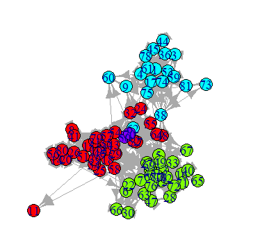

UKfaculty network colored by Attribute group

```r
# Check the attributes available in the dataset
vertex_attr_names(UKfaculty)

# Assuming 'Group' is an attribute in the dataset
# Assign different colors to each unique group
group_colors <- rainbow(length(unique(V(UKfaculty)$Group)))

# Create a vector of colors for each vertex based on its group
vertex_colors <- group_colors[V(UKfaculty)$Group]

# Plot the graph with vertex colors based on the 'Group' attribute
plot(UKfaculty, vertex.color = vertex_colors)
```

Denotes the social phenomenon that people tend to be similar to their social contacts.

Birds of a feather - Billie Eilish has the same title as one of the most cited homophily papers by McPherson, Smith-Lovin and Cook (2001), where various studies of homophily were summarised. Homophily is observed in regard to race and ethnicity, gender and age, religion, education, occupation and social class, behaviour, and attitudes and beliefs

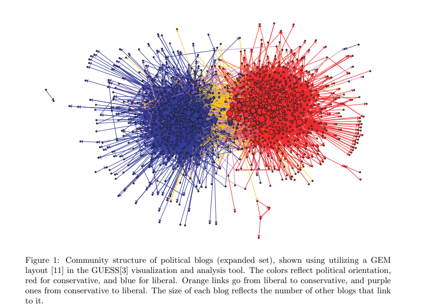

(Adamic and Glance 2005)

Other, *secondary types of homophily* can reinforce segregation on an attribute. Example: Ethnic segregation can be reinforced by socioeconomic homophily, when ethnic origin (node color) and socioeconomic status (node shape) overlap (e.g., many ethnic minority members have a lower socioeconomic status and many ethnic majority members have a higher socioeconomic status)

For an explanation see (Wimmer and Lewis 2010, 588–94)

### Measurement of segregation:

```r
g <- data(UKfaculty)
UKfaculty

group1 <- V(g)[Group == 1]
```

We can also use the **assortavity coefficient** for measurement.

Assortavity coefficients are basically correlation coefficients that (in the case of categorical variables) can be measured by $e_{i,j}$ being the ratio of edge from actors of type $i$ to type $j$

Let $e_{ij}$ be the ratio of edges from actors of type $i$ to type $j$.

$a_i = \sum_j e_{ij} \quad \text{(ratio of edges outgoing from actors of type \( i \))}$

$b_j = \sum_i e_{ij} \quad \text{(ratio of edges incoming to actors of type \( j \))}$

The assortativity coefficient ( r ) is defined as:

$$r = \frac{\sum_{i}e_{ii}-\sum_{i}a_ib_i}{1-\sum_{i}a_ib_i}$$

$r = 0 \quad \text{if} \quad e_{ii} = a_i b_i \quad \text{(random connections)}$

$r = 1 \quad \text{if} \quad \text{only actors of the same type are connected}$

$r = - \frac{\sum_i a_i b_i}{1 - \sum_i a_i b_i} \quad \text{if} \quad \text{only actors of different types are connected}$

```r
# types are assumed to be integers starting with one
assortativity_nominal(UKfaculty, types = V(UKfaculty)$Group + 1)
```

or odds-ratios of within-group ties (Bojanowski and Corten 2014)

```r
orwg(UKfaculty, "Group")
```

or Colemans Index (Coleman 1958) that compares the proportion of same-group neighbours to the proportion of that group in the network as a whole.

```r
coleman(UKfaculty, "Group")
```

which compares the proportion of same-group neighbors to the proportion of that group in the network as a whole. It is a number between -1 and 1. Value of 0 means these proportions are equal. Value of 1 means that all ties outgoing from a particular group are sent to the members of the same group. Value of -1 is the opposite – all ties are sent to members of other group(s).

### Measurement of homophily

Measuring homophily preferences is difficult as we cannot directly observe preferences. In the social networks literature, the most common ways to estimate the strength of homophily preferences are Exponential Random Graph Models (ERGMs) and Stochastic Actor-Oriented Models (SAOMs). These estimate the existence of ties in dependence of actor attributes (such as similarity). While we shortly be talking about these models in week 7, I still want to point out the caveat of ERGMs and SAOMs that they rely on a revealed preference assumption and infer preferences from the observed network structure.

Another approach to testing homophily preferences are **permutation tests**. A permutation is the result of a random reshuffle of the row and column names in an adjacency matrix. This creates a random network with the same structural properties (e.g., reciprocated ties) as the observed network. Who is connected to whom is, however different now. The level of segregation in the permuted network is now solely based on the network composition. If we permute the network a large number of times, we receive a distribution of segregation values expected due to the network composition. Then, we can test whether the observed segregation is statistically significant from the distribution of permutations. A significant difference tells us that preferences are (likely) the reason for the difference between the mean of the permutations and the observation. **We, however, do not know which preferences are responsible!**

**Reflective question**: From what stage on, can we say a network is homophile or segregated?

## Triadic closure and forbidden triads

Granovetters paper is one of the most cited papers in sociology (right after Foucault) and social network analysis. It has been cited 76.037 (last checked on 04/28/25) times and is considered foundational work in the field of social network analysis. The concept of the strength of weak ties has been widely applied in various fields, including sociology, communication studies, and organizational behavior.

Following Granovetter, the strength of ties is measured by the *amount of time, emotional intensity, intimacy, and reciprocal services **that characterize the tie. Granovetter explicitly differentiates between** strong **and** weak ties*.

Networks follow a so called **transitivity tendency** meaning that if $A$ is connected to $B$ and $C$, then $B$ and $C$ are more likely to be (positively) connected to each other than if $A$ was not connected to either of them. This is also called the **triadic closure** property of networks. This is due to meeting opportunities, homophily and structural balance.

Following these arguments, Granovetter calls triads, in which $A$ has strong ties to $B$ and $C$, but no tie exists between $B$ and $C$, **forbidden triads**. He argues that these triads are unstable and will be dissolved over time. Empirically forbidden triads occur in core networks.

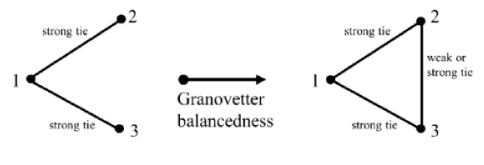

Forbidden triad (left) and stable triad (right) (Tutić and Wiese 2015)

With this in mind, Granovetter argues that the transitivity tendency a function of strength of ties and not a general property of networks. Going through the mechanisms that drive the transitivity tendency. this becomes more obvious.

1. **Meeting opportunities**: If $A$ has weak ties to $B$ and $C$, they less often interact if it where strong ties. This means that the likelihood of $B$ and $C$ meeting is lower than if $A$ has strong ties to both of them.
2. **Homophily**: People have a preference to interact with people who are similar to them. If they aren’t relationsships are probably more superficial and instrumental. This means that the likelihood of $B$ and $C$ being similar is lower than if $A$ has strong ties to both of them.
3. **Balance theory**: In the case of weak ties, people are less strained by cognitive disbalance.

This is also empirically supported: Core networks of friends have stronger triadic closure than peripheral networks of acquaintances.

# Vertex importance

The fact that people play different roles and have different influences inside groups and communities has motivated centuries of sociological and psychological research, so it is unsurprising that the concept of vertex importance and influence is of great interest in the study of people or organizational networks.

But importance and influence are not precisely defined concepts, and to make them real within the context of graphs and networks we need to find some sort of *mathematical definition* for them. In many visual graph layouts, more important or influential vertices that have stronger roles in overall connectivity will usually be positioned toward the center of a group of other vertices. Intuitively therefore, we use the term ‘centrality’ to describe the importance or influence of a vertex in the connected structure of a graph.

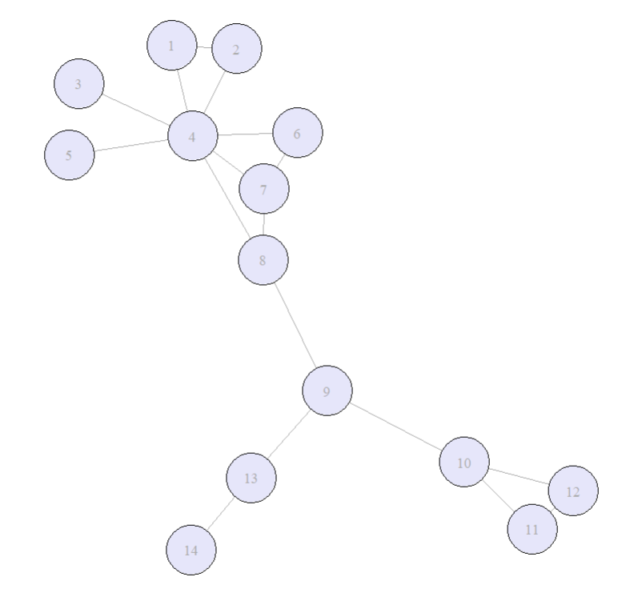

Network with 14 vertices and 17 edges

```r
# Edgelist from Ona Book
g <- graph_from_literal(1--2, 3--4, 4--1, 4--2, 4--5, 4--6, 6--7, 4--6, 7--8, 8--4, 8--9, 9--10, 10--11, 11--12, 9--13, 13--14, 11--12, 12--10, 7--4)

ecount(g)


V(g)$color <- "lavender"
V(g)$label.color <- "darkgrey"

# Plotten
plot(g,
     vertex.size = 20,
     vertex.label.cex = 0.8)
```

### Degree centrality

The degree centralty (or *valence*) of a vertex $v$ is the number of edges connected to $v$. Its thus a measure of immediate connections. Related to the concept of degree is the ego size. The $n$th order ego network of a given vertex $v$ is the set including $v$ itself and all vertices that are reachable from $v$ by a path of length $n$. The size of the $n$ th order ego network is the number of vertices in it.

**Out-degree**: the number of edges going out from a vertex.

**In-degree**: the number of edges going into a vertex.

```r
# degree centrality in r
degree(g, mode = "all")

degree(UKfaculty, mode = "in")
degree(UKfaculty, mode = "out")
```

### Closeness centrality:

The closeness centrality of a vertec $x$ in a connected graph is the inverse of the sum of the distances from $x$ to all other vertices. Through inverting the distancematrix we make sure, that lower total distances will generate higher closeness centrality scores. In connected graphs is defined as:

$$C_B(x) = \frac{1}{\sum_{y \in V} d(x,y)}$$

where $d(x,y)$ is the distance between vertices $x$ and $y$.

```r
closeness(g, mode = "all")

closeness(UKfaculty, mode = "in")
closeness(UKfaculty, mode = "out")
```

### Betweenness centrality:

The betweenness centrality of a vertex $v$ is the number of shortest paths between all pairs of vertices that pass through $v$. In connected graphs is defined as:

$$C_B(v) = \sum_{s. t \in V \\ s \neq v \neq t} \frac{\sigma_{st}(v)}{\sigma_{st}}$$

where $\sigma_{st}$ is the number of shortest paths between vertices $s$ and $t$ and $\sigma_{st}(v)$ is the number of those paths that pass through $v$.

```r
betweenness(g, directed = FALSE)

betweenness(UKfaculty, directed = TRUE)
```

### Eigenvector centrality:

The Eigenvector centrality (or *prestige*) is a measure of how connected a vertex is to other influential vertices in the graph. Relative scores are assigned to each vertex based on the scores of its neighbors. It can be calculated using the adjacency matrix of the graph.

For a given graph $G$ = (V,E), let $A = (a_{v,t})$ be the adjacency matrix, i.e. $a_{v,t} = 1$ if vertex $v$ is linked to vertex $t$, and $a_{v,t} = 0$ otherwise. The relative centrality score, $x_v$, of vertex $v$ can be defined as:

$${\displaystyle x_{v}={\frac {1}{\lambda }}\sum _{t\in M(v)}x_{t}={\frac {1}{\lambda }}\sum _{t\in V}a_{v,t}x_{t}}$$

where $M(v)$ is the set of neighbors of vertex $v$ and $\lambda$ is a constant. The centrality score of a vertex is proportional to the sum of the centrality scores of its neighbors. The constant $\lambda$ is the largest eigenvalue of the adjacency matrix.

```r
eigen_centrality(g, directed = FALSE)
eigen_centrality(UKfaculty, directed = TRUE)
```

We have not looked at the impact of edge weights on centrality in this chapter. This is because it is unusual to consider edge weights in centrality measures. However most centrality measures can be adapted to take edge weights into account. This could be an interesting lookout as a subject for your final project.

### Local clustering coefficient:

The local clustering coefficient gives an indication of the of the extend of clustering of a single vertex (How close its neighbors are to being a clique (complete graph).

Let $G = (V, E)$ be an undirected simple graph[^1] with $V$ vertices and $E$ edges. $n$ is the total number of vertices in the graph, $m$ the total number of edges.

The neighborhood $N_i$ of a vertex $v_i$ are its immediate neighbors and defined as followed:

$$N_i = \{v_j : e_{ij} \in E \wedge e_{ji} \in E\}$$

We define $k_i$ as he number of vertices $|N_i|$ in the neighborhood of $v_i$. The local clustering coefficient of a vertex $v_i$ is the proportion of edges between the vertices within its neighborhood divided by the number of edges that could possibly exist between them.

Thus we define the local clustering coefficient of a vertex $v_i$ as:

$$C_i = \frac{\{|e_{jk} : v_j, v_k \in N_i, e_{jk} \in E|\}}{k_i (k_i-1)}$$

where $e_{ij}$ is the number of edges between the vertices in the neighborhood of $v_i$ and $k_i$ is the number of vertices in the neighborhood of $v_i$.

```r
transitivity(UKfaculty, type = "local")
```

Which node in the network g has the highest

1. Degree centrality
2. Closeness centrality
3. Betweenness centrality
4. Local clustering coefficient?

Think about it first and then check your results using R.

# The strength of weak ties

Granovetter’s theory of the strength of weak ties suggests that weak ties (i.e., acquaintances) can be more valuable than strong ties (i.e., close friends) in terms of information flow and access to new opportunities. This is because weak ties often connect individuals to different social groups, providing access to diverse information and resources that may not be available within one’s immediate social circle.

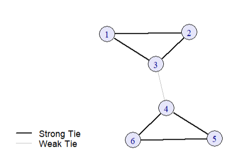

Weak ties

```r
# Define the edges
edges <- c(
  1,2, 1,3, 2,3,    # Triad 1: nodes 1,2,3 fully connected
  4,5, 4,6, 5,6,    # Triad 2: nodes 4,5,6 fully connected
  3,4               # Weak tie between the two triads
)

# Create the graph
weak <- make_graph(edges, directed = FALSE)

# Plot the graph
plot(weak,
  vertex.size=30,
  vertex.color = "lavender",
  edge.width=c(rep(2,6), 0.5),  # Thicker edges within triads, thin edge for weak tie
  edge.color=c(rep("black",6), "gray")
  )  # Force-directed layout for nice separation

# Add a legend
legend("bottomleft",
    legend = c("Strong Tie", "Weak Tie"),
    col = c("black", "gray"),
    lwd = c(2, 1),
    bty = "n")
```

The connection between the two triads is a weak tie, while the connections within each triad are strong ties. The weak tie (3-4) allows for information flow between the two otherwise disconnected groups.

Remember last session:

1. What is a bridge?
2. What is a cutpoint?

## Local bridges and structural holes

Empirically, bridges are extremely rare in social networks.

[figure not shown]

Bridge in the FSR-Logo network

This is why we also introduce the notion of **local bridges**.

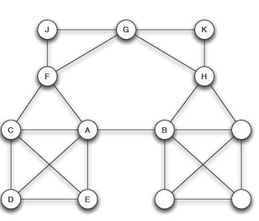

Local bridges

Edge {A,B} is a local bridge if its endpoints $A$ and $B$ have no contacts in common. So if deleting the edge will increase the distance between $A$ and $B$ with more than 2. So it provides their endpoints with access to parts of the network that otherwise would be far away.

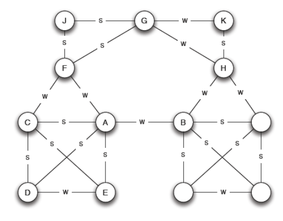

Classification of links

Following Granovetters ideas on triadic closure, why must every local bridge be a weak tie?

While most social structures tend to be characterized by dense clusters of strong connections, some individuals can act as mediators between these clusters. These individuals are often referred to as **brokers** and according to Burt (1995) they can benefit from their position as brokers between two or more groups. Burt calls the space between two groups a **structural hole**.

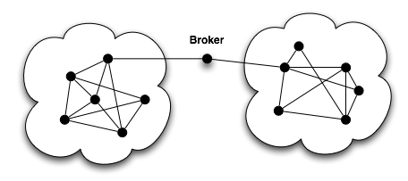

Positions at structural holes

Burt introduces the measurement of **constraint** to measure the degree to which a vertex is constrained by its neighbours.

**High constraint** = your friends know each other a lot → your network is tight and redundant.

**Low constraint** = your friends are mostly independent → you can bridge different groups (you have more “social capital”).

- $C_i$ is the constraint of vertex $i$.
- $V_i$ is the set of vertices that are neighbours of $i$.
- $p_{ij}$ is the proportion of ties between $i$ and $j$.
- $a_{ij}$ is the strength of tie between $i$ and $j$.

$$C_i = \sum_{j \in V_i \setminus \{i\}} \left( p_{ij} + \sum_{q \in V_i \setminus \{i,j\}} p_{iq} p_{qj} \right)^2$$

```r
constraint(g,
          nodes = V(g),
          weights = NULL
)
```

## References

Adamic, Lada, and Natalie Glance. 2005. “The Political Blogosphere and the 2004 U.S. Election: Divided They Blog.”

Bojanowski, Michał, and Rense Corten. 2014. “Measuring Segregation in Social Networks.” *Social Networks* 39 (October): 14–32. https://doi.org/10.1016/j.socnet.2014.04.001.

Bourdieu, Pierre. 1986. “The Forms of Capital.” In *Handbook of Theory and Research for the Sociology of Education*, 241–85. Greenwood: Westport CT.

Burt, Ronald S. 1995. *Structural Holes: The Social Structure of Competition*. Reprint edition. Cambridge, Mass: Harvard University Press.

Cartwright, D., and F. Harary. 1956. “Structural Balance: A Generalization of Heider’s Theory.” *Psychological Review* 63 (5): 277–93. https://doi.org/10.1037/h0046049.

Coleman, James S. 1958. “Relational Analysis: The Study of Social Organizations with Survey Methods.” *Human Organization* 17 (4): 28–36. https://www.jstor.org/stable/44124097.

Davis, James A., and Samuel Leinhardt. 1967. “The Structure of Positive Interpersonal Relations in Small Groups.”

Easley, David, and Jon Kleinberg. 2010. *Networks, Crowds, and Markets: Reasoning about a Highly Connected World*. 1st ed. Cambridge University Press. https://doi.org/10.1017/CBO9780511761942.

Granovetter, Mark S. 1973. “The Strength of Weak Ties.” *American Journal of Sociology* 78 (6): 1360–80. https://www.jstor.org/stable/2776392.

Lin, Nan. 2001. *Social Capital: A Theory of Social Structure and Action*. 1st ed. Cambridge University Press. https://doi.org/10.1017/CBO9780511815447.

Moody, James. 2001. “Race, School Integration, and Friendship Segregation in America.” *American Journal of Sociology* 107 (3): 679–716. https://doi.org/10.1086/338954.

Putnam, Robert D. 2001. *Bowling Alone: The Collapse and Revival of American Community*. 1. Touchstone ed. A Touchstone Book. London: Simon & Schuster [u.a.].

Stehlé, Juliette, François Charbonnier, Tristan Picard, Ciro Cattuto, and Alain Barrat. 2013. “Gender Homophily from Spatial Behavior in a Primary School: A Sociometric Study.” *Social Networks* 35 (4): 604–13. https://doi.org/10.1016/j.socnet.2013.08.003.

Tutić, Andreas, and Harald Wiese. 2015. “Reconstructing Granovetter’s Network Theory.” *Social Networks* 43 (October): 136–48. https://doi.org/10.1016/j.socnet.2015.05.002.

Wimmer, Andreas, and Kevin Lewis. 2010. “Beyond and Below Racial Homophily: ERG Models of a Friendship Network Documented on Facebook.” *American Journal of Sociology* 116 (2): 583–642. https://doi.org/10.1086/653658.

## Footnotes

[^1]: A simple graph is a graph that does not contain multiple edges or loops.

## Copyright

© 2026 Leonie Steinbrinker